# FigureYa211multiCohortImmSubtype

**Author(s)**: Xiaofan Lu  
**Reviewers**: Ying Ge,Hui Huang  
**Date**: 2025-12-25

## 1 Academic Citation

If you use this code in your work or research, we kindly request that you cite our publication:

Xiaofan Lu, et al. (2025). FigureYa: A Standardized Visualization Framework for Enhancing Biomedical Data Interpretation and Research Efficiency. iMetaMed. https://doi.org/10.1002/imm3.70005

## 2 需求描述 Requirement Description

以往的分子分型都是基于基因表达来做的，这有一个是基于多数据集免疫细胞的，输出Fig.1 A和B。

In the past, molecular typing was based on gene expression, but one of them is based on multiple datasets of immune cell. Outputs Fig.1 A and B.

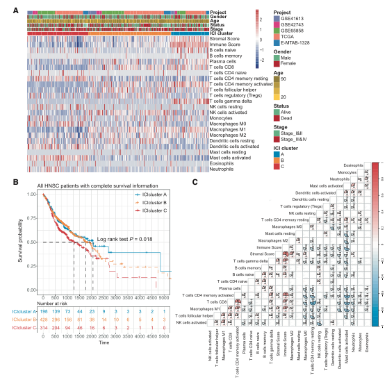

From https://www.cell.com/molecular-therapy-family/nucleic-acids/fulltext/S2162-2531(20)30259-6

Figure 1. The Landscape of Immuno-cell Infiltration in the TME of HNSC (A) Unsupervised clustering of tumor-infiltrating immune cells in five independent HNSC cohorts. Rows represent tumor-infiltrating immune cells, and columns represent samples. (B) Kaplan-Meier curves for overall survival (OS) of all HNSC patients with immune cell-infiltrating classes. Log rank test showed an overall p = 0.018.

跟FigureYa201ClusterCorrelation、FigureYa203ComBat、FigureYa204PCAscore出自同一篇文章。

It’s from the same article as FigureYa201ClusterCorrelation, FigureYa203ComBat, and FigureYa204PCAscore.

## 3 应用场景 Application Scenarios

不同平台的表达谱，去除批次效应后，计算免疫富集，并进行分子分型与生存分析。

Expression profiles of different platforms, after removing batch effects, immune enrichment was calculated, and molecular typing and survival analysis were performed.

We performed the CIBERSORT and ESTIMATE algorithms to quantify the activity or enrichment levels of immune cells in HNSC tumor tissues

## 4 环境设置 Environment settings

```r
source("install_dependencies.R")
```

[output not shown]

[output not shown]

```
## Bioconductor version 3.21 (BiocManager 1.30.27), R 4.5.1 (2025-06-13)
```

```
## Installing package(s) 'immunedeconv'
```

[output not shown]

```r
library(sva) # ComBat去除批次效应 # ComBat removes batch effects
library(ConsensusClusterPlus) # 共识聚类 # Consensus clustering
library(survminer) # 生存分析 # Survival analysis
library(survival) # 生存分析 # Survival analysis
library(tidyestimate) # 计算ESTIMATE得分 # Calculate ESTIMATE score (replaces old estimate package)
library(pheatmap) # 热图 # Heatmap
source("CIBERSORT.R")

Sys.setenv(LANGUAGE = "en") #显示英文报错信息 # error messages are displayed in English
options(stringsAsFactors = FALSE) #禁止chr转成factor # chr is not allowed to be converted to factor
```

自定义函数，用于数据标准化并截断极端值 Custom functions for data normalization and truncation of extreme values

```r
standarize.fun <- function(indata=NULL, halfwidth=NULL, centerFlag=T, scaleFlag=T) {
  outdata=t(scale(t(indata), center=centerFlag, scale=scaleFlag))
  if (!is.null(halfwidth)) {
    outdata[outdata>halfwidth]=halfwidth
    outdata[outdata<(-halfwidth)]= -halfwidth
  }
  return(outdata)
}
```

## 5 输入文件 Input files

表达矩阵文件，数据下载和预处理可参考FigureYa203ComBat。

TCGA hnsc的表达数据和生存信息：tcga_hnsc.expr.txt和tcga_hnsc.surv.txt。可以用TCGAbiolinks下载，或从[xena](https://xenabrowser.net/datapages/)下载。

来自GEO的芯片数据和生存信息：gse41613.expr.txt和gse41613.surv.txt，gse65858.expr.txt和gse65858.surv.txt

The expression matrix file, the data download and preprocessing can be found in FigureYa203ComBat.

Expression data and survival information :tcga_hnsc.expr.txt and tcga_hnsc.surv.txt of TCGA hnsc. It can be downloaded with TCGAbiolinks, or from [xena](https://xenabrowser.net/datapages/)

Chip data and survival information from GEO:gse41613.expr.txt and gse41613.surv.txt, gse65858.expr.txt and gse65858.surv.txt

### 5.1 加载不同平台的表达谱、去除批次效应 Load expression profiles from different platforms to remove batch effects

```r
# 加载预处理过的表达谱
# Load the pre-treated expression spectrum
tcga.expr <- read.csv("tcga_hnsc.expr.txt",sep = "\t",row.names = 1,check.names = F,stringsAsFactors = F,header = T)
gse41613.expr <- read.table("gse41613.expr.txt",sep = "\t",row.names = 1,check.names = F,stringsAsFactors = F,header = T)
gse65858.expr <- read.table("gse65858.expr.txt",sep = "\t",row.names = 1,check.names = F,stringsAsFactors = F,header = T)

# 检查数据量级
# Check the amount of data
range(tcga.expr) # 量级很大取对数 # The magnitude is very large and logarithm
```

```
## [1]     0.00 97511.89
```

```r
tcga.expr <- log2(tcga.expr + 1)
range(tcga.expr) # 量级在0-20 # On the magnitude of 0-20
```

```
## [1]  0.00000 16.57331
```

```r
range(gse41613.expr) # 量级在0-20 # On the magnitude of 0-20
```

```
## [1]  1.237778 16.238890
```

```r
range(gse65858.expr) # 量级在0-20 # On the magnitude of 0-20
```

```
## [1]  5.3782 14.2618
```

```r
# 合并数据集检查批次效应
# Merge datasets to check batch effect
comgene <- intersect(intersect(rownames(tcga.expr), rownames(gse41613.expr)), rownames(gse65858.expr))
combined.expr <- cbind.data.frame(tcga.expr[comgene,],
                                  gse41613.expr[comgene,],
                                  gse65858.expr[comgene,])

# combat去除批次再次检查
# combat remove the batch and check it again
batch <- data.frame(batch = rep(c("TCGA","GSE41613","GSE65858"), times = c(ncol(tcga.expr),ncol(gse41613.expr),ncol(gse65858.expr))))
modcombat = model.matrix(~1, data = batch)
combined.expr.combat <- as.data.frame(ComBat(dat=as.matrix(combined.expr), batch=batch$batch, mod=modcombat))
```

```
## Found3batches
```

```
## Adjusting for0covariate(s) or covariate level(s)
```

```
## Standardizing Data across genes
```

```
## Fitting L/S model and finding priors
```

```
## Finding parametric adjustments
```

```
## Adjusting the Data
```

```r
# 保存到txt格式的文件
# Save to a file in txt format
write.table(combined.expr.combat,"output_combined_expr.txt",sep = "\t",row.names = T,col.names = NA,quote = F)
```

### 5.2 加载生存数据，用于生存分析 Load survival data for survival analysis

```r
tcga.surv <- read.table("tcga_hnsc.surv.txt",sep = "\t",row.names = 1,check.names = F,stringsAsFactors = F,header = T)
tcga.surv <- as.data.frame(na.omit(tcga.surv)) # 去除空值 # Remove null values
rownames(tcga.surv) <- paste0(rownames(tcga.surv),"-01")
gse41613.surv <- read.table("gse41613.surv.txt",sep = "\t",row.names = 1,check.names = F,stringsAsFactors = F,header = T)
gse65858.surv <- read.table("gse65858.surv.txt",sep = "\t",row.names = 1,check.names = F,stringsAsFactors = F,header = T)

# 根据数据将时间转化为月份
# Convert time to months based on data
tcga.surv$OS.time <- tcga.surv$OS.time/30.5
gse65858.surv$OS.time <- gse65858.surv$OS.time/30.5

# 合并生存时间
# Merge time-to-live
tcga.surv$Project <- "TCGA"
gse41613.surv$Project <- "GSE41613"
gse65858.surv$Project <- "GSE65858"
combined.surv <- rbind.data.frame(tcga.surv[,c("OS","OS.time","Project")],
                                  gse41613.surv[,c("OS","OS.time","Project")],
                                  gse65858.surv[,c("OS","OS.time","Project")])
```

## 6 计算ESTIMATE得分 Calculate ESTIMATE score

使用tidyestimate包计算得分 (替代旧的estimate包)。

Use tidyestimate package to calculate scores (replaces old estimate package).

```r
# 读取表达矩阵 # Read expression matrix
combined.expr.combat <- read.table("output_combined_expr.txt", sep = "\t", row.names = 1, check.names = F, stringsAsFactors = F, header = T)

# 使用tidyestimate包计算得分 # Use tidyestimate package to calculate scores
# 当tidy=FALSE时，基因标识符在行名中 # When tidy=FALSE, gene identifiers are in rownames
filtered_data <- filter_common_genes(combined.expr.combat,
                                     id = "hgnc_symbol",
                                     tidy = FALSE,
                                     tell_missing = TRUE,
                                     find_alias = FALSE)
```

```
##
## The following genes are in the list of common genes, but not in your dataset:
##
## NAT2 CDH4 CDH7 CDH8 CDH9 CDH10 CDH12 CDH15 CDH17 CDH18...and 2498 others
```

```
##
## Found 7883 of 10391 genes (75.864%) in your dataset.
```

```r
# 计算ESTIMATE得分 # Calculate ESTIMATE scores
est.result <- estimate_score(filtered_data, is_affymetrix = FALSE)  # 使用合并数据，通常不是Affymetrix平台 # Using merged data, usually not Affymetrix platform
```

```
## Number of stromal_signature genes in data: 123 (out of 141)
```

```
## Number of immune_signature genes in data: 132 (out of 141)
```

```r
# 转换数据格式为兼容后续分析的格式 # Convert data format for compatibility with subsequent analysis
# estimate_score返回格式：sample, stromal, immune, estimate
# 需要转置为：行=得分类型，列=样本 # Need to transpose to: rows=score types, columns=samples
sample_names <- est.result$sample
est.result <- est.result[, c("stromal", "immune", "estimate")]  # 只选择数值列 # Select only numeric columns
est.result <- t(est.result)  # 转置 # Transpose
rownames(est.result) <- c("StromalScore", "ImmuneScore", "ESTIMATEScore")
colnames(est.result) <- sample_names

# 保存结果到文件 # Save results to file
write.table(est.result, "output_combined_expr_estimate_score.txt", sep = "\t", row.names = T, col.names = NA, quote = F)
```

## 7 Run CIBERSORT

原文：Infiltration levels for distinct immune cells in HNSC were quantified by using “CIBERSORT” R package and employing the LM22 signature and 1,000 permutations.

使用CIBERSORT前，请先注册https://cibersort.stanford.edu，查看教程http://cibersort.stanford.edu/tutorial.php

- LM22.txt，注册后即可下载。

original paper:Infiltration levels for distinct immune cells in HNSC were quantified by using “CIBERSORT” R package and employing the LM22 signature and 1,000 permutations.

before use CIBERSORT Please register for https://cibersort.stanford.edu first to view the tutorial http://cibersort.stanford.edu/tutorial.php

- LM22.txt, you can download it after registration.

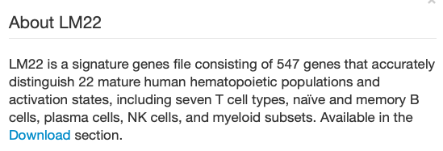

- output_combined_expr.txt，上一步整合好的表达矩阵和生存信息。
- output_combined_expr.txt, the previous step integrates the expression matrix and survival information.

```r
#这步运行时间较长
# This step takes a long time to run
ciber.res <- CIBERSORT(sig_matrix = "LM22.txt",
                       mixture_file = "output_combined_expr.txt",
                       perm = 100,
                       QN = TRUE)
# 保存到文件
# Save to file
write.table(ciber.res,"CIBERSORT result.txt",sep = "\t",row.names = T,col.names = NA,quote = F)
```

## 8 共识PAM聚类 Consensus PAM clustering

The unsupervised clustering “Pam” method based on Euclidean and Ward’s linkage was used in this analysis, executed by using the “ConsensuClusterPlus” R package,23 and repeated 1,000 times to ensure the classification stability.

```r
est <- read.table("output_combined_expr_estimate_score.txt",sep = "\t",row.names = 1,check.names = F,stringsAsFactors = F,header = T)
# tidyestimate输出的格式已经正确，不需要再处理 # tidyestimate output format is already correct, no need for additional processing
# 列名应该已经是正确的样本名 # Column names should already be correct sample names

ciber.res <- read.table("CIBERSORT result.txt", sep = "\t", row.names = 1, header = T, check.names = F)
head(ciber.res)
```

```
##                 B cells naive B cells memory Plasma cells T cells CD8
## TCGA-CQ-5332-01   0.000000000     0.00000000   0.05327316 0.051693484
## TCGA-F7-7848-01   0.000000000     0.07080402   0.02387736 0.112861355
## TCGA-CV-7414-01   0.006074927     0.00000000   0.03778841 0.000000000
## TCGA-BA-A6DA-01   0.000000000     0.01231243   0.05109046 0.109247093
## TCGA-CQ-6227-01   0.028311652     0.00000000   0.00000000 0.008320106
## TCGA-CV-7432-01   0.000000000     0.00000000   0.00000000 0.022489594
##                 T cells CD4 naive T cells CD4 memory resting
## TCGA-CQ-5332-01       0.000000000                 0.03403355
## TCGA-F7-7848-01       0.000000000                 0.08341039
## TCGA-CV-7414-01       0.000000000                 0.15908841
## TCGA-BA-A6DA-01       0.007738976                 0.08766657
## TCGA-CQ-6227-01       0.000000000                 0.00000000
## TCGA-CV-7432-01       0.000000000                 0.22626025
##                 T cells CD4 memory activated T cells follicular helper
## TCGA-CQ-5332-01                   0.00000000               0.006604884
## TCGA-F7-7848-01                   0.07725252               0.000000000
## TCGA-CV-7414-01                   0.00000000               0.093450747
## TCGA-BA-A6DA-01                   0.07601887               0.000000000
## TCGA-CQ-6227-01                   0.00000000               0.035664514
## TCGA-CV-7432-01                   0.14127468               0.000000000
##                 T cells regulatory (Tregs) T cells gamma delta NK cells resting
## TCGA-CQ-5332-01                 0.06309650          0.00000000       0.00899562
## TCGA-F7-7848-01                 0.03284186          0.06841471       0.02794649
## TCGA-CV-7414-01                 0.14837435          0.00000000       0.05342309
## TCGA-BA-A6DA-01                 0.00000000          0.00000000       0.00000000
## TCGA-CQ-6227-01                 0.03600988          0.05747571       0.00000000
## TCGA-CV-7432-01                 0.00000000          0.00000000       0.05617623
##                 NK cells activated  Monocytes Macrophages M0 Macrophages M1
## TCGA-CQ-5332-01         0.00000000 0.00000000     0.21858694     0.00000000
## TCGA-F7-7848-01         0.00000000 0.00000000     0.12013675     0.03343912
## TCGA-CV-7414-01         0.15975912 0.01564150     0.15730218     0.07397563
## TCGA-BA-A6DA-01         0.05710196 0.00000000     0.10854753     0.03739447
## TCGA-CQ-6227-01         0.01203532 0.00000000     0.26693727     0.14879872
## TCGA-CV-7432-01         0.00000000 0.01083345     0.05871502     0.12560475
##                 Macrophages M2 Dendritic cells resting
## TCGA-CQ-5332-01     0.11769609            0.0003008927
## TCGA-F7-7848-01     0.14692557            0.0032916558
## TCGA-CV-7414-01     0.00000000            0.0076699601
## TCGA-BA-A6DA-01     0.08925322            0.0000000000
```

[output cut: 8 more lines]

```
## TCGA-CV-7432-01                0.00000000         0.00000000
##                 Mast cells activated Eosinophils Neutrophils P-value
## TCGA-CQ-5332-01           0.41026147  0.01270854 0.000000000    0.00
## TCGA-F7-7848-01           0.16075746  0.00000000 0.025036233    0.00
## TCGA-CV-7414-01           0.02349813  0.00000000 0.000000000    0.00
## TCGA-BA-A6DA-01           0.28164186  0.00000000 0.062504244    0.07
## TCGA-CQ-6227-01           0.29738000  0.00000000 0.000000000    0.00
## TCGA-CV-7432-01           0.21166254  0.00000000 0.003985386    0.01
##                 Correlation      RMSE
## TCGA-CQ-5332-01   0.4223292 0.9202354
## TCGA-F7-7848-01   0.2969303 0.9615140
## TCGA-CV-7414-01   0.2937982 0.9757574
## TCGA-BA-A6DA-01   0.1376479 1.0399844
## TCGA-CQ-6227-01   0.3246225 0.9805888
## TCGA-CV-7432-01   0.2002262 1.0097029
```

```r
# 合并ESTIMATE获得的activity of immune cells(est)和CIBERSORT获得的enrichment levels of immune cells(ciber.res)
# Merge the activity of immune cells (est) obtained from ESTIMATE and the enrichment levels of immune cells obtained by CIBERSORT (ciber.res)
ciber.res <- ciber.res[,1:22]
ciber.res <- ciber.res[,colSums(ciber.res) > 0] # 去除丰度均为0的细胞 # Remove cells with 0 abundance
input_data <- cbind.data.frame(ciber.res,
                               ImmuneScore = as.numeric(est["ImmuneScore",rownames(ciber.res)]), # 添加免疫富集 # Add immune enrichment
                               StromalScore = as.numeric(est["StromalScore",rownames(ciber.res)])) # 添加基质富集 # Add matrix enrichment

indata <- t(scale(input_data))

# 这一步，我运行了 < 10 min
# For this step, I ran < for 10 min
cc <- ConsensusClusterPlus(d = indata,
                           maxK = 3, # 三类 # Three categories
                           reps = 1000, # 重抽样次数，可修改 # Number of resamples, modifiable
                           pItem = 0.8, # 列维度抽样概率，可修改 # Column dimension sampling probability, modifiable
                           pFeature = 1, # 行维度抽样概率，可修改 # Row dimension sampling probability, modifiable
                           clusterAlg = "pam", # 聚类算法，可修改 # Clustering algorithm, modifiable
                           innerLinkage = "ward.D", # 内部链接函数，可修改 # Internal link function, modifiable
                           finalLinkage = "ward.D", # 最终链接函数，可修改 # Last-link function, modifiable
                           distance = "euclidean", # 距离测度，可修改 # Distance measurement, modifiable
                           seed = 19991018,
                           title = "ConsensusCluster",
                           plot = "pdf")
```

```
## end fraction
```

```
## clustered
## clustered
```

```r
ICIcluster <- cc[[3]]$consensusClass

# 为生存分析作准备
# Prepare for survival analysis
comsam <- intersect(rownames(combined.surv),colnames(indata))
combined.surv[comsam,"ICIcluster"] <- ifelse(ICIcluster[comsam] == 1, "A", # 这里把有生存信息的数据的ICIcluster补上以便后面进行生存分析 # # Here we add the ICIcluster with survival information for survival analysis later
                                             ifelse(ICIcluster[comsam] == 2, "B", "C"))
```

## 9 开始画图 Start drawing

### 9.1 热图 Heatmap

```r
# 设置颜色
# Set the color

blue <- "#2874C5"
yellow <- "#EABF00"
green <- "#008B8A"
red <- "#E21F26"

# 生成热图
# Generate a heatmap
annCol <- data.frame(ICIcluster = ifelse(ICIcluster == 1,"A", ifelse(ICIcluster == 2, "B", "C")),
                     Project = rep(c("TCGA","GSE41613","GSE65858"),c(ncol(tcga.expr),ncol(gse41613.expr),ncol(gse65858.expr))),
                     stringsAsFactors = F)
annCol <- annCol[order(annCol$ICIcluster,annCol$Project),] # 这里对每个ICIcluster内部的cohort进行排序，使得相同cohort的样本彼此靠近 # Here the cohorts inside each ICIcluster are sorted so that the samples of the same cohort are close to each other

annColors <- list()
annColors[["ICIcluster"]] <- c("A" = red,
                               "B" = blue,
                               "C" = yellow)

annColors[["Project"]] <- c("TCGA" = red,
                            "GSE41613" = blue,
                            "GSE65858" = yellow)

plotdata <- standarize.fun(indata,halfwidth = 2) # 数据标准化并截断极端值 # Data is normalized and truncated to extreme values
pheatmap(plotdata[,rownames(annCol)],
         cluster_cols = F,
         color = colorRampPalette(c("#282B71","white","#CF2221"))(64),  # 使用现代colorRampPalette替代NMF:::ccRamp # Use modern colorRampPalette instead of NMF:::ccRamp
         show_rownames = T,
         show_colnames = F,
         annotation_col = annCol[,c("ICIcluster","Project"),drop = F],
         annotation_colors = annColors,
         treeheight_col = 0,
         treeheight_row = 0,
         filename = "ICIcluster.pdf")
```

[figure not shown]

### 9.2 生存分析 Survival Analysis

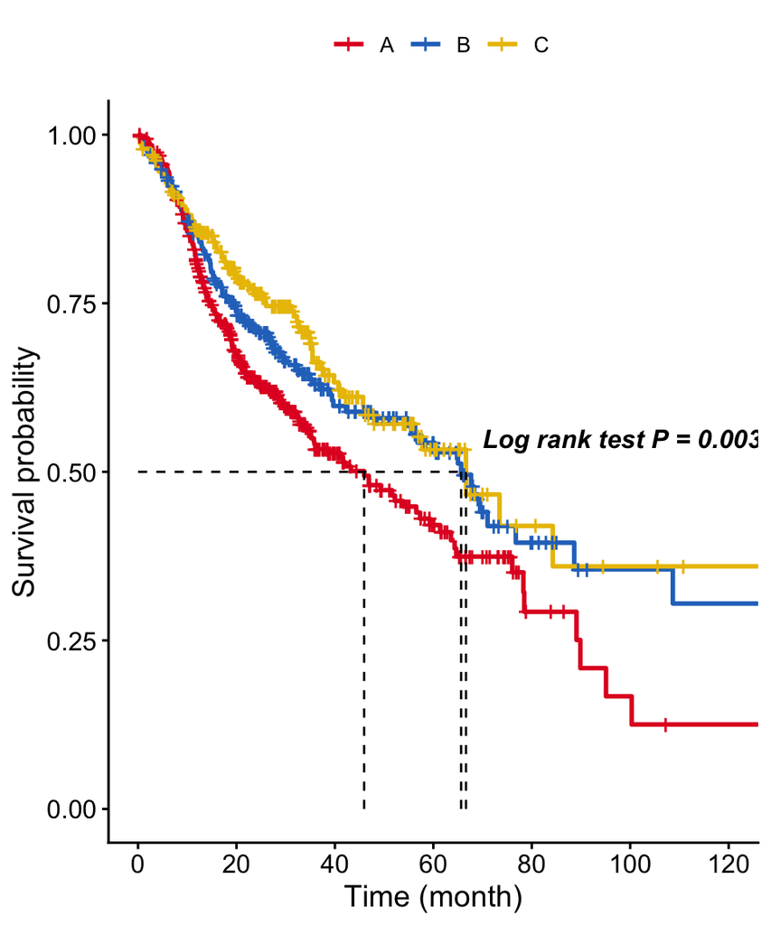

```r
fitd <- survdiff(Surv(OS.time, OS) ~ ICIcluster,
                 data      = combined.surv,
                 na.action = na.exclude)
p.val <- 1 - pchisq(fitd$chisq, length(fitd$n) - 1)
fit <- survfit(Surv(OS.time, OS)~ ICIcluster,
               data      = combined.surv,
               type      = "kaplan-meier",
               error     = "greenwood",
               conf.type = "plain",
               na.action = na.exclude)

# hack strata for better survival curve
names(fit$strata) <- gsub("ICIcluster=", "", names(fit$strata))

# kaplan-meier curve
p <- ggsurvplot(fit               = fit,
                conf.int          = FALSE,
                risk.table        = TRUE,
                risk.table.col    = "strata",
                palette           = c(red, blue, yellow),
                data              = combined.surv,
                size              = 1,
                xlim              = c(0,120),
                break.time.by     = 20,
                legend.title      = "",
                pval              = FALSE, # 不计算p值，改为手动添加 # The p-value is not calculated, and is added manually
                surv.median.line  = "hv",
                xlab              = "Time (month)",
                ylab              = "Survival probability",
                risk.table.y.text = FALSE)

p.lab <- paste0("Log rank test P", # p值文本 # P-value text
                ifelse(p.val < 0.001, " < 0.001",
                       paste0(" = ",round(p.val, 3))))

p$plot <- p$plot + annotate("text", # 手动添加例文样式的p值 # Manually add the p-value of the example style
                            x = 70,
                            y = 0.55,
                            hjust = 0,
                            fontface = 4,
                            label = p.lab)
p$plot
```

```r
pdf.options(reset = TRUE, onefile = FALSE)
pdf("km curve of ICIcluster.pdf", width = 5, height = 6)
print(p)
dev.off()
```

## 10 关键更新要点 Key Updates Summary

- **依赖包现代化**：替换旧的 `estimate` 包为新的 `tidyestimate` 包，使用 `filter_common_genes` 和 `estimate_score` 函数替代旧的 `filterCommonGenes` 和 `estimateScore`
- **函数名称更新**：tidyestimate使用现代R命名规范（snake_case），与旧estimate包的camelCase命名不同
- **数据格式兼容性**：tidyestimate要求当 `tidy=FALSE` 时基因标识符在行名中，输出格式为tibble，需要适当的格式转换（移除了旧代码中不必要的列名处理）
- **平台检测改进**：使用 `is_affymetrix` 参数替代 `platform` 参数，更清晰地指定数据平台类型（TRUE/FALSE 代替字符串）
- **颜色函数现代化**：替换过时的 `NMF:::ccRamp` 函数为现代的 `colorRampPalette`，确保与新R版本的兼容性，避免对已废弃NMF包的依赖
- **Dependency Modernization**: Replaced the deprecated `estimate` package with the modern `tidyestimate` package, using `filter_common_genes` and `estimate_score` functions instead of the old `filterCommonGenes` and `estimateScore`
- **Function Name Updates**: tidyestimate uses modern R naming conventions (snake_case), different from the old estimate package’s camelCase naming
- **Data Format Compatibility**: tidyestimate requires gene identifiers in rownames when `tidy=FALSE`, and returns tibble format requiring appropriate conversions (removed unnecessary column name processing from old code)
- **Platform Detection Improvements**: Uses `is_affymetrix` parameter (TRUE/FALSE) instead of `platform` parameter (string) for clearer data platform specification
- **Color Function Modernization**: Replaced the outdated `NMF:::ccRamp` function with modern `colorRampPalette` to ensure compatibility with newer R versions and avoid dependency on deprecated NMF package